# Course Project 1: Reproducible Research

Maura Bardos

October 12, 2018

```r
library(rmarkdown)
library(dplyr)
library(chron)
```

# Introduction

This report describes data analysis for data from a personal activity monitoring device. The data (Activity.csv) was downloaded from the course website. This device collects data at 5 minute intervals through out the day. The data consists of two months of data from an anonymous individual collected during the months of October and November, 2012 and include the number of steps taken in 5 minute intervals each day.

The dataset has three variables and 17,568 observations. variables include steps, date, and interval. Steps are the number of steps taking in a 5-minute interval (missing values are coded as NA). Time interval refers to the 5-minute interval in which measurement was taken

# Loading and preprocessing the data

Data for the analysis was loaded into R. Data preprocessing was performed to ensure that the date variable was formatted correclty.

```r
activity <- read.csv("./activity.csv", stringsAsFactors=FALSE)
activity$date <- as.Date(activity$date)
```

# Descriptive Analysis

## Total, Average, and Median Steps per Day

First, descriptive statistics on steps per day were computed and the total, average, and median steps per day can be seen in the table below.

```r
steps_by_day <- activity %>%
  group_by(date) %>%
  summarize(sumsteps = sum(steps, na.rm = TRUE), meansteps = mean(steps, na.rm = TRUE),
            mediansteps = median(steps, na.rm = TRUE))
```

Summary Statistics of Steps per Day

| date | sumsteps | meansteps | mediansteps |
| --- | --- | --- | --- |
| 2012-10-01 | 0 | NaN | NA |
| 2012-10-02 | 126 | 0.4375000 | 0 |
| 2012-10-03 | 11352 | 39.4166667 | 0 |
| 2012-10-04 | 12116 | 42.0694444 | 0 |
| 2012-10-05 | 13294 | 46.1597222 | 0 |
| 2012-10-06 | 15420 | 53.5416667 | 0 |
| 2012-10-07 | 11015 | 38.2465278 | 0 |
| 2012-10-08 | 0 | NaN | NA |
| 2012-10-09 | 12811 | 44.4826389 | 0 |
| 2012-10-10 | 9900 | 34.3750000 | 0 |
| 2012-10-11 | 10304 | 35.7777778 | 0 |
| 2012-10-12 | 17382 | 60.3541667 | 0 |
| 2012-10-13 | 12426 | 43.1458333 | 0 |
| 2012-10-14 | 15098 | 52.4236111 | 0 |
| 2012-10-15 | 10139 | 35.2048611 | 0 |
| 2012-10-16 | 15084 | 52.3750000 | 0 |
| 2012-10-17 | 13452 | 46.7083333 | 0 |
| 2012-10-18 | 10056 | 34.9166667 | 0 |
| 2012-10-19 | 11829 | 41.0729167 | 0 |
| 2012-10-20 | 10395 | 36.0937500 | 0 |
| 2012-10-21 | 8821 | 30.6284722 | 0 |
| 2012-10-22 | 13460 | 46.7361111 | 0 |
| 2012-10-23 | 8918 | 30.9652778 | 0 |
| 2012-10-24 | 8355 | 29.0104167 | 0 |
| 2012-10-25 | 2492 | 8.6527778 | 0 |
| 2012-10-26 | 6778 | 23.5347222 | 0 |
| 2012-10-27 | 10119 | 35.1354167 | 0 |
| 2012-10-28 | 11458 | 39.7847222 | 0 |
| 2012-10-29 | 5018 | 17.4236111 | 0 |
| 2012-10-30 | 9819 | 34.0937500 | 0 |
| 2012-10-31 | 15414 | 53.5208333 | 0 |
| 2012-11-01 | 0 | NaN | NA |
| 2012-11-02 | 10600 | 36.8055556 | 0 |
| 2012-11-03 | 10571 | 36.7048611 | 0 |
| 2012-11-04 | 0 | NaN | NA |
| 2012-11-05 | 10439 | 36.2465278 | 0 |
| 2012-11-06 | 8334 | 28.9375000 | 0 |
| 2012-11-07 | 12883 | 44.7326389 | 0 |
| 2012-11-08 | 3219 | 11.1770833 | 0 |
| 2012-11-09 | 0 | NaN | NA |
| 2012-11-10 | 0 | NaN | NA |
| 2012-11-11 | 12608 | 43.7777778 | 0 |
| 2012-11-12 | 10765 | 37.3784722 | 0 |
| 2012-11-13 | 7336 | 25.4722222 | 0 |
| 2012-11-14 | 0 | NaN | NA |
| 2012-11-15 | 41 | 0.1423611 | 0 |
| 2012-11-16 | 5441 | 18.8923611 | 0 |
| 2012-11-17 | 14339 | 49.7881944 | 0 |
| 2012-11-18 | 15110 | 52.4652778 | 0 |
| 2012-11-19 | 8841 | 30.6979167 | 0 |
| 2012-11-20 | 4472 | 15.5277778 | 0 |
| 2012-11-21 | 12787 | 44.3993056 | 0 |
| 2012-11-22 | 20427 | 70.9270833 | 0 |
| 2012-11-23 | 21194 | 73.5902778 | 0 |
| 2012-11-24 | 14478 | 50.2708333 | 0 |
| 2012-11-25 | 11834 | 41.0902778 | 0 |
| 2012-11-26 | 11162 | 38.7569444 | 0 |
| 2012-11-27 | 13646 | 47.3819444 | 0 |
| 2012-11-28 | 10183 | 35.3576389 | 0 |
| 2012-11-29 | 7047 | 24.4687500 | 0 |
| 2012-11-30 | 0 | NaN | NA |

The distribution of steps per day was computed and is shown in a histogram

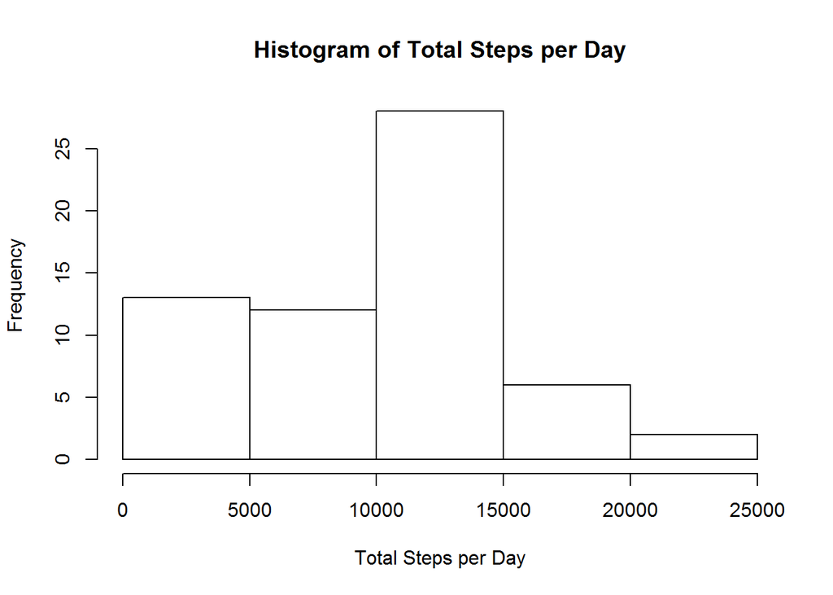

```r
hist(steps_by_day$sumsteps, main = "Histogram of Total Steps per Day", xlab = "Total Steps per Day")
```

## Average Daily Activity Patterns

Next, time series plots were explored to examine the average number steps by 5-minute interval.

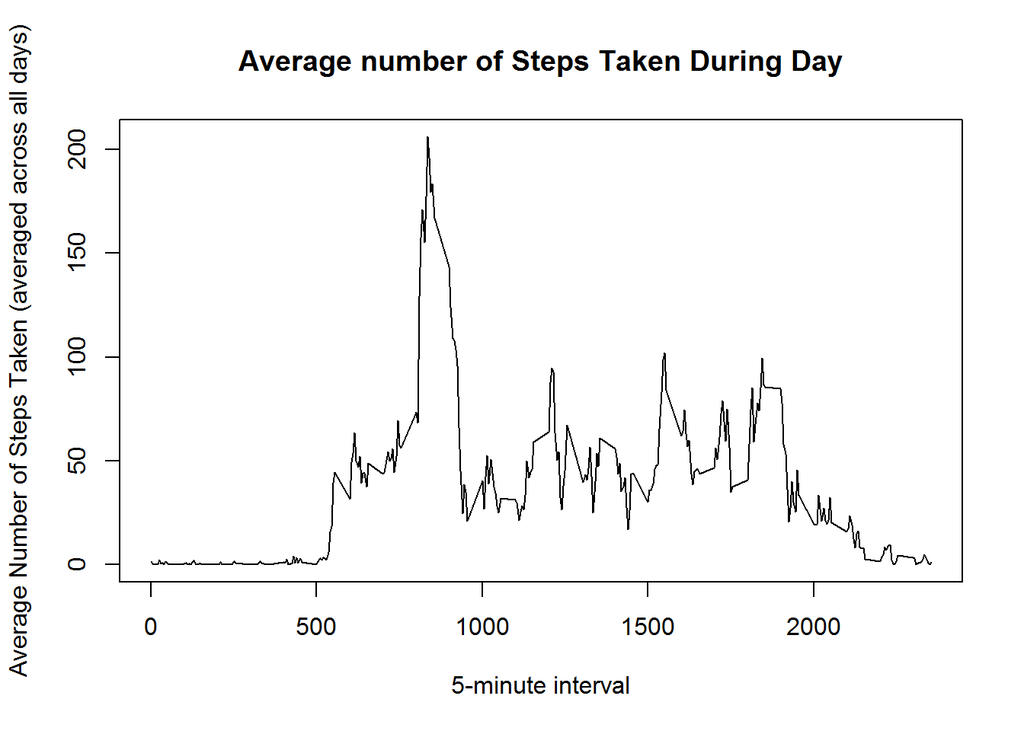

```r
steps_by_interval <- activity %>%
  group_by(interval) %>%
  summarize(meansteps = mean(steps, na.rm = TRUE))


plot( steps_by_interval$interval, steps_by_interval$meansteps, type = "l", xlab = "5-minute interval",
      ylab = "Average Number of Steps Taken (averaged across all days)", main = "Average number of Steps Taken During Day")
```

```r
max_steps_interval <-  steps_by_interval %>%
  arrange(desc(meansteps))

max_steps <- max_steps_interval$interval[1]
```

The the maximum number of steps on average occurs at the 5-minute interval of 835.

## Imputing Missing Values

Next, we look at missing values to determine their potential impact on our analysis.

```r
missing_rows <- sum(is.na(activity$steps))

activity_impute <- activity
activity_impute$steps[is.na(activity$steps)] <- mean(activity_impute$steps, na.rm = TRUE)
```

The total number of rows with missing values is 2304. Missing values only occur in the variable steps.

To impute missing values, we use simple mean imputation and and create a new dataset called activity_imputed. The histogram for activity_imputed shows that a larger proportion of the data is now centered around the mean. This is because we imputed mean values for any NAs in the orignal dataset.

```r
steps_by_day_i <- activity_impute %>%
  group_by(date) %>%
  summarize(sumsteps = sum(steps, na.rm = TRUE), meansteps = mean(steps, na.rm = TRUE),
            mediansteps = median(steps, na.rm = TRUE))
```

Summary Statistics of Steps per Day for Imputed Data

| date | sumsteps | meansteps | mediansteps |
| --- | --- | --- | --- |
| 2012-10-01 | 10766.19 | 37.3825996 | 37.3826 |
| 2012-10-02 | 126.00 | 0.4375000 | 0.0000 |
| 2012-10-03 | 11352.00 | 39.4166667 | 0.0000 |
| 2012-10-04 | 12116.00 | 42.0694444 | 0.0000 |
| 2012-10-05 | 13294.00 | 46.1597222 | 0.0000 |
| 2012-10-06 | 15420.00 | 53.5416667 | 0.0000 |
| 2012-10-07 | 11015.00 | 38.2465278 | 0.0000 |
| 2012-10-08 | 10766.19 | 37.3825996 | 37.3826 |
| 2012-10-09 | 12811.00 | 44.4826389 | 0.0000 |
| 2012-10-10 | 9900.00 | 34.3750000 | 0.0000 |
| 2012-10-11 | 10304.00 | 35.7777778 | 0.0000 |
| 2012-10-12 | 17382.00 | 60.3541667 | 0.0000 |
| 2012-10-13 | 12426.00 | 43.1458333 | 0.0000 |
| 2012-10-14 | 15098.00 | 52.4236111 | 0.0000 |
| 2012-10-15 | 10139.00 | 35.2048611 | 0.0000 |
| 2012-10-16 | 15084.00 | 52.3750000 | 0.0000 |
| 2012-10-17 | 13452.00 | 46.7083333 | 0.0000 |
| 2012-10-18 | 10056.00 | 34.9166667 | 0.0000 |
| 2012-10-19 | 11829.00 | 41.0729167 | 0.0000 |
| 2012-10-20 | 10395.00 | 36.0937500 | 0.0000 |
| 2012-10-21 | 8821.00 | 30.6284722 | 0.0000 |
| 2012-10-22 | 13460.00 | 46.7361111 | 0.0000 |
| 2012-10-23 | 8918.00 | 30.9652778 | 0.0000 |
| 2012-10-24 | 8355.00 | 29.0104167 | 0.0000 |
| 2012-10-25 | 2492.00 | 8.6527778 | 0.0000 |
| 2012-10-26 | 6778.00 | 23.5347222 | 0.0000 |
| 2012-10-27 | 10119.00 | 35.1354167 | 0.0000 |
| 2012-10-28 | 11458.00 | 39.7847222 | 0.0000 |
| 2012-10-29 | 5018.00 | 17.4236111 | 0.0000 |
| 2012-10-30 | 9819.00 | 34.0937500 | 0.0000 |
| 2012-10-31 | 15414.00 | 53.5208333 | 0.0000 |
| 2012-11-01 | 10766.19 | 37.3825996 | 37.3826 |
| 2012-11-02 | 10600.00 | 36.8055556 | 0.0000 |
| 2012-11-03 | 10571.00 | 36.7048611 | 0.0000 |
| 2012-11-04 | 10766.19 | 37.3825996 | 37.3826 |
| 2012-11-05 | 10439.00 | 36.2465278 | 0.0000 |
| 2012-11-06 | 8334.00 | 28.9375000 | 0.0000 |
| 2012-11-07 | 12883.00 | 44.7326389 | 0.0000 |
| 2012-11-08 | 3219.00 | 11.1770833 | 0.0000 |
| 2012-11-09 | 10766.19 | 37.3825996 | 37.3826 |
| 2012-11-10 | 10766.19 | 37.3825996 | 37.3826 |
| 2012-11-11 | 12608.00 | 43.7777778 | 0.0000 |
| 2012-11-12 | 10765.00 | 37.3784722 | 0.0000 |
| 2012-11-13 | 7336.00 | 25.4722222 | 0.0000 |
| 2012-11-14 | 10766.19 | 37.3825996 | 37.3826 |
| 2012-11-15 | 41.00 | 0.1423611 | 0.0000 |
| 2012-11-16 | 5441.00 | 18.8923611 | 0.0000 |
| 2012-11-17 | 14339.00 | 49.7881944 | 0.0000 |
| 2012-11-18 | 15110.00 | 52.4652778 | 0.0000 |
| 2012-11-19 | 8841.00 | 30.6979167 | 0.0000 |
| 2012-11-20 | 4472.00 | 15.5277778 | 0.0000 |
| 2012-11-21 | 12787.00 | 44.3993056 | 0.0000 |
| 2012-11-22 | 20427.00 | 70.9270833 | 0.0000 |
| 2012-11-23 | 21194.00 | 73.5902778 | 0.0000 |
| 2012-11-24 | 14478.00 | 50.2708333 | 0.0000 |
| 2012-11-25 | 11834.00 | 41.0902778 | 0.0000 |
| 2012-11-26 | 11162.00 | 38.7569444 | 0.0000 |
| 2012-11-27 | 13646.00 | 47.3819444 | 0.0000 |
| 2012-11-28 | 10183.00 | 35.3576389 | 0.0000 |
| 2012-11-29 | 7047.00 | 24.4687500 | 0.0000 |
| 2012-11-30 | 10766.19 | 37.3825996 | 37.3826 |

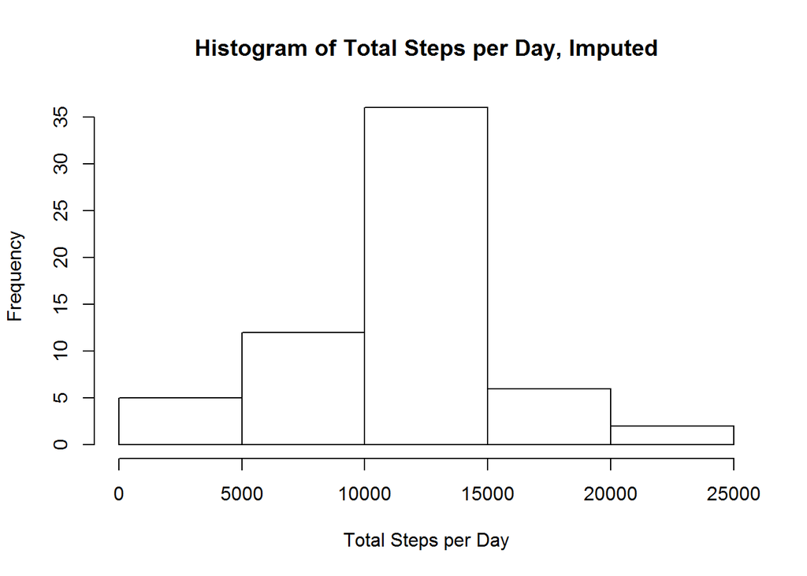

```r
hist(steps_by_day_i$sumsteps, main = "Histogram of Total Steps per Day, Imputed", xlab = "Total Steps per Day")
```

## Analysis of Weekdays versus Weekends

To analyze differences in steps between weekdays and weekends, we create a variable to classify the date by weekday or weekend. The time series plot of the 5-minute interval and average number of steps taken, averaged across all weekdays or weekends is plotted.

The plot indicates that the maximum number of average steps taken is greater on weekdays is greater than weekends. However, there is variability in average steps throught the day for a weekend day than weekday.

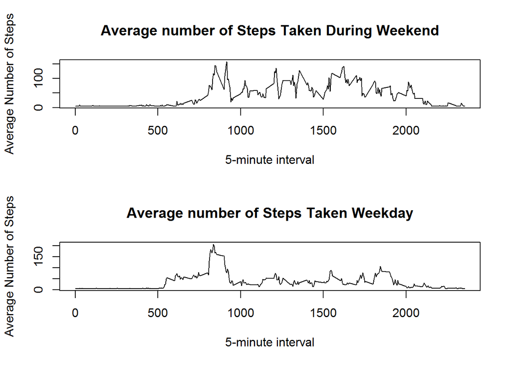

```r
activity_impute$weekend = chron::is.weekend(activity_impute$date)
activity_impute_weekend <- activity_impute[which(activity_impute$weekend == "TRUE"),]
activity_impute_weekday <- activity_impute[which(activity_impute$weekend == "FALSE"),]


steps_by_interval_weekend <- activity_impute_weekend%>%
  group_by(interval) %>%
  summarize(meansteps = mean(steps, na.rm = TRUE))

steps_by_interval_weekday <- activity_impute_weekday%>%
  group_by(interval) %>%
  summarize(meansteps = mean(steps, na.rm = TRUE))

par(mfrow=c(2,1))

plot(steps_by_interval_weekend$interval, steps_by_interval_weekend$meansteps, type = "l", xlab = "5-minute interval",
      ylab = "Average Number of Steps", main = "Average number of Steps Taken During Weekend")

plot( steps_by_interval_weekday$interval, steps_by_interval_weekday$meansteps, type = "l", xlab = "5-minute interval",
      ylab = "Average Number of Steps", main = "Average number of Steps Taken Weekday")
```